# Package Presentation: Phyloseq

Mariana Acevedo Garcia

2025-11-26

# Introduction to Phyloseq

Phyloseq uses many tools available in R for ecology, phylogenetics, and graphing such as vegan, ade4, ape, picante, and ggplot2 to analyze and visually explore phylogenetic sequencing data that has been organized into Operational Taxonomic Units (OTUs). It is especially useful when accompanying sample metadata, a phylogenetic tree and/or taxonomic classifications of the OTUs are available.

I am particularly interested in using phyloseq for its microbiome plot functions and ability to merge data based on OTU or sample variables. They also have thorough analysis and graphing tutorials using published data to make learning the package more approachable.

Most information I am presenting comes from Dr. Paul J. McMurdie and Dr. Nicholas Ollberding, to learn more in depth about phyloseq check out their websites:  
- https://www.nicholas-ollberding.com/post/introduction-to-phyloseq/ - https://joey711.github.io/phyloseq/index.html

## Installing Phyloseq & Loading Packages

There are a few ways to install phyloseq, this is what worked for my computer:

```
source("http://bioconductor.org/biocLite.R")
biocLite('phyloseq')
source("https://raw.githubusercontent.com/joey711/phyloseq/master/inst/scripts/installer.R", local = TRUE)
```

```r
library(ggplot2)
library("phyloseq")
library("ape")
library("plyr")
library("Biostrings")
library(tidyverse)
theme_set(theme_bw())
```

# Example Workflows

## Santa Rita Experimental Range Data

To begin learning phyloseq, which I plan to use for analyzing my data in the future, I made graphs using different datasets.

First, I used data from the Santa Rita Experimental Range (SRER), a NEON agricultural research station near Tucson, Arizona. The site supports the collection of diverse environmental data to advance research on desert ecosystems. For this analysis, I used 2024 soil metadata, which includes sequencing data from numerous soil samples.

**Load Data**

```r
summary<-readRDS("C:/Users/marac/Downloads/summary-of-dada2-2.RDS")
ASVTable<-readRDS("C:/Users/marac/Downloads/seqtab_final-2.RDS")
Taxa<-readRDS("C:/Users/marac/Downloads/taxa-2.RDS")

meta <- read.csv("C:/Users/marac/Downloads/mmg_metadata_16SrRNA_QCd_20240222-2.csv")
```

**Introduce Data to Phyloseq**

```r
#Build a phyloseq object (ps) by assembling all your ASV counts, metadata, and taxonomy
ps <- phyloseq(otu_table(ASVTable, taxa_are_rows=FALSE),
               sample_data(Meta),
               tax_table(Taxa))

#Convert ASV sequences into DNA sequence objects
#Give each DNA sequence the same name as its ASV, so they will merge correctly
dna <- Biostrings::DNAStringSet(taxa_names(ps))
names(dna) <- taxa_names(ps)

#Merge the DNA sequences into the existing phyloseq object
ps <- merge_phyloseq(ps,dna)

#Replace long DNA sequence names with ASV labels
taxa_names(ps) <- paste0("ASV", seq(ntaxa(ps)))
```

**Familiarize Yourself with the Data**

These functions are helpful to get to know your data

```r
ntaxa(ps)
```

```
## [1] 95595
```

```r
nsamples(ps)
```

```
## [1] 234
```

```r
sample_names(ps)[1:5]
```

```
## [1] "BMI_18S_07_0575_16S_C983L" "BMI_18S_07_0576_16S_C983L"
## [3] "BMI_18S_07_0577_16S_C983L" "BMI_18S_07_0578_16S_C983L"
## [5] "BMI_18S_07_0579_16S_C983L"
```

```r
rank_names(ps)
```

```
## [1] "Kingdom" "Phylum"  "Class"   "Order"   "Family"  "Genus"
```

```r
sample_variables(ps)[1:5]
```

```
## [1] "uid.rawFiles"           "setDate"                "processedDate.rawFiles"
## [4] "sequencerRunID"         "dnaSampleID"
```

```r
otu_table(ps)[1:5,1:4]
```

```
## OTU Table:          [4 taxa and 5 samples]
##                      taxa are columns
##                           ASV1 ASV2 ASV3 ASV4
## BMI_18S_07_0575_16S_C983L    0    0    0    0
## BMI_18S_07_0576_16S_C983L    0    0    0    0
## BMI_18S_07_0577_16S_C983L    0    0    0    0
## BMI_18S_07_0578_16S_C983L    0    0    0    0
## BMI_18S_07_0579_16S_C983L    0    0    0    0
```

```r
tax_table(ps)[1:5,1:4]
```

```
## Taxonomy Table:     [5 taxa by 4 taxonomic ranks]:
##      Kingdom    Phylum             Class                 Order
## ASV1 "Bacteria" "Proteobacteria"   "Alphaproteobacteria" "Rhizobiales"
## ASV2 "Bacteria" "Proteobacteria"   "Gammaproteobacteria" "Burkholderiales"
## ASV3 "Bacteria" "Proteobacteria"   "Gammaproteobacteria" "Nitrosococcales"
## ASV4 "Bacteria" "Proteobacteria"   "Alphaproteobacteria" "Sphingomonadales"
## ASV5 "Bacteria" "Actinobacteriota" "Thermoleophilia"     "Gaiellales"
```

**Plot Alpha Diversity**

Alpha diversity measures the variation of species in an ecosystem or sample. Shannon index gives an idea of the overall community structure by considering species abundance and evenness. Simpson index emphasizes dominant species, so it is useful for comparing different communities.

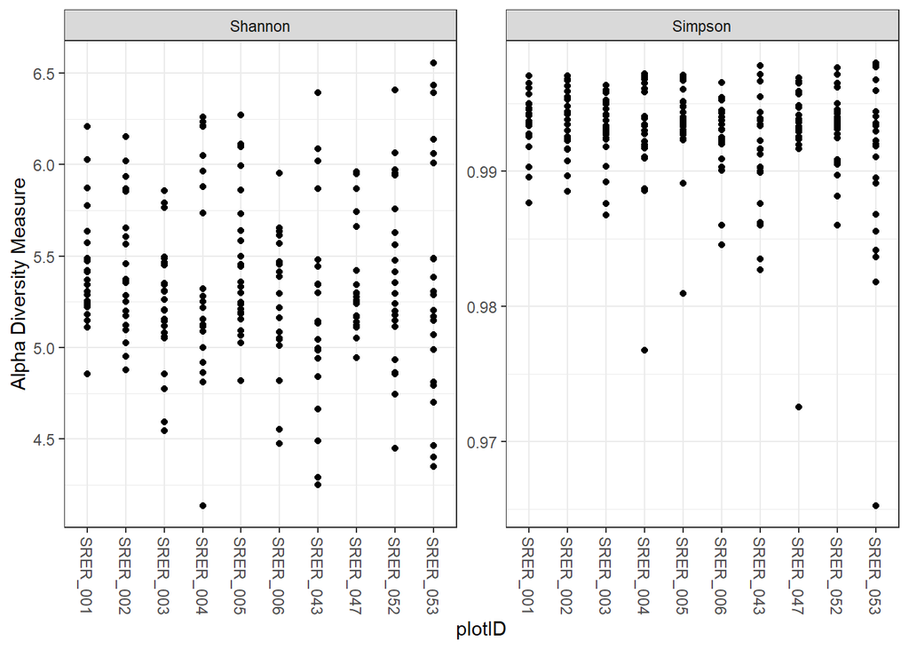

```r
#Convert counts to relative abundance
ps_relative = transform_sample_counts(ps, function(x) x / sum(x))

#Remove very rare ASVs, keep only those whose average relative abundance across samples is greater than 0.001%
ps_filtered = filter_taxa(ps_relative, function(x) mean(x) > 1e-5, TRUE)

#Create a richness plot showing Shannon and Simpson diversity by plot ID
plot_richness(ps_filtered, x="plotID", measures=c("Shannon", "Simpson"))
```

## GlobalPatterns Data

I used this dataset and a tutorial from Dr. Paul J. McMurdie to learn how to plot ordination and perform a Principal Coordinate Analysis (PCA).

**Load & Familiarize Yourself with GlobalPatterns**

```r
data("GlobalPatterns")
GP = GlobalPatterns

?GlobalPatterns

ntaxa(GlobalPatterns)
```

```
## [1] 19216
```

```r
nsamples(GlobalPatterns)
```

```
## [1] 26
```

```r
sample_names(GlobalPatterns)
```

```
##  [1] "CL3"      "CC1"      "SV1"      "M31Fcsw"  "M11Fcsw"  "M31Plmr"
##  [7] "M11Plmr"  "F21Plmr"  "M31Tong"  "M11Tong"  "LMEpi24M" "SLEpi20M"
## [13] "AQC1cm"   "AQC4cm"   "AQC7cm"   "NP2"      "NP3"      "NP5"
## [19] "TRRsed1"  "TRRsed2"  "TRRsed3"  "TS28"     "TS29"     "Even1"
## [25] "Even2"    "Even3"
```

```r
rank_names(GlobalPatterns)
```

```
## [1] "Kingdom" "Phylum"  "Class"   "Order"   "Family"  "Genus"   "Species"
```

```r
sample_variables(GlobalPatterns)
```

```
## [1] "X.SampleID"               "Primer"
## [3] "Final_Barcode"            "Barcode_truncated_plus_T"
## [5] "Barcode_full_length"      "SampleType"
## [7] "Description"
```

```r
otu_table(GlobalPatterns)[1:5,1:5]
```

```
## OTU Table:          [5 taxa and 5 samples]
##                      taxa are rows
##        CL3 CC1 SV1 M31Fcsw M11Fcsw
## 549322   0   0   0       0       0
## 522457   0   0   0       0       0
## 951      0   0   0       0       0
## 244423   0   0   0       0       0
## 586076   0   0   0       0       0
```

```r
tax_table(GlobalPatterns)[1:5,1:4]
```

```
## Taxonomy Table:     [5 taxa by 4 taxonomic ranks]:
##        Kingdom   Phylum          Class          Order
## 549322 "Archaea" "Crenarchaeota" "Thermoprotei" NA
## 522457 "Archaea" "Crenarchaeota" "Thermoprotei" NA
## 951    "Archaea" "Crenarchaeota" "Thermoprotei" "Sulfolobales"
## 244423 "Archaea" "Crenarchaeota" "Sd-NA"        NA
## 586076 "Archaea" "Crenarchaeota" "Sd-NA"        NA
```

```r
phy_tree(GlobalPatterns)
```

```
##
## Phylogenetic tree with 19216 tips and 19215 internal nodes.
##
## Tip labels:
##   549322, 522457, 951, 244423, 586076, 246140, ...
## Node labels:
##   , 0.858.4, 1.000.154, 0.764.3, 0.995.2, 1.000.2, ...
##
## Rooted; includes branch length(s).
```

**Filter Data**

These filtering steps were done to create a clear, straightforward graph. But, Dr. McMurdie warns against filtering data without biological reasons, so these steps may not apply to all datasets.

```r
#Filtering data to only keep taxa that have more than 5 reads in at least 50% of samples, removes rare taxa
wh0 = genefilter_sample(GP, filterfun_sample(function(x) x > 5),
                       A = 0.5*nsamples(GP))

#Prune the phyloseq object to keep only the filtered taxa from the previous line of code
GP1 = prune_taxa(wh0, GP)

#Normalize sequencing data by converting counts to counts per million
GP1 = transform_sample_counts(GP1, function(x) 1E6 * x/sum(x))

#Create a vector with total abundance for each phylum
phylum.sum = tapply(taxa_sums(GP1), tax_table(GP1)[, "Phylum"], sum, na.rm = TRUE)

#Identify and keep the 5 most abundant phyla
top5phyla = names(sort(phylum.sum, TRUE))[1:5]
GP1 = prune_taxa((tax_table(GP1)[, "Phylum"] %in% top5phyla), GP1)
```

**Plot Ordination**

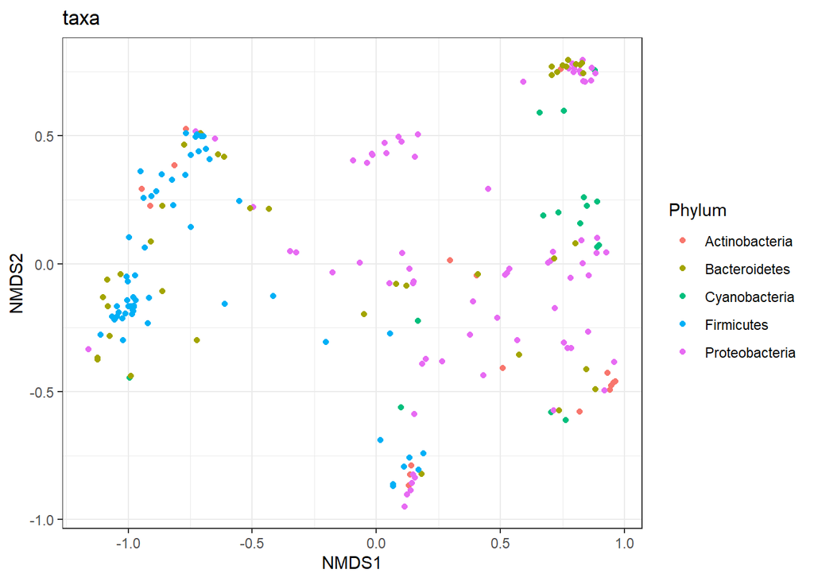

```r
#Define a human associated versus non-human categorical variable
human = get_variable(GP1, "SampleType") %in% c("Feces", "Mock", "Skin", "Tongue")
sample_data(GP1)$human <- factor(human)

#Compute an NMDS ordination using Bray-Curtis distances - creates an ordination to visualize how similar or different taxa are based on their abundances
#Plot taxa and color by phylum
GP.ord <- ordinate(GP1,"NMDS","bray", trymax = 20, trace = FALSE)
p1 = plot_ordination(GP1, GP.ord, type = "taxa", color = "Phylum", title = "taxa")
print(p1)
```

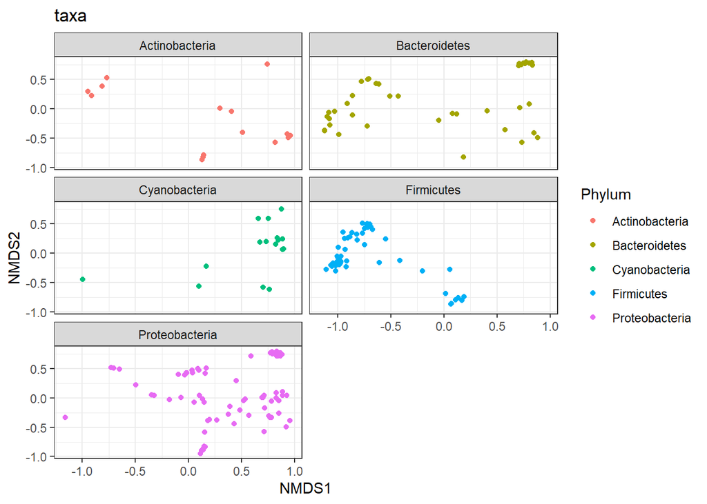

```r
#Create faceted plots by phylum - creates separate panels for each phylum
p1 + facet_wrap(~Phylum,3)
```

**Perform Ordination Using PCoA**

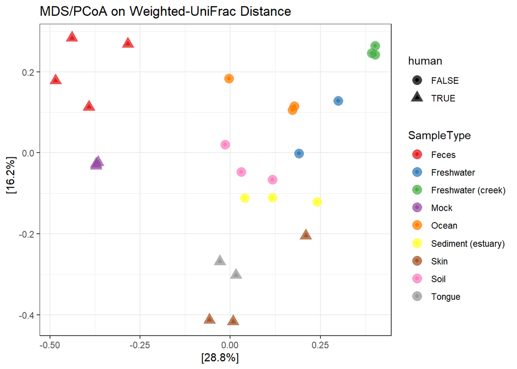

```r
#Run a Principal Coordinates Analysis (PCaA) using UniFrac distance, a phylogeny-aware metric
ordu = ordinate(GP1, "PCoA", "unifrac", weighted = TRUE)

#Create an ordination plot using the PCoA results
#Points will be colored based on sample type and shaped based on whether they are human associated
p = plot_ordination(GP1, ordu, color = "SampleType", shape = "human")

#Make the graph look nicer with ggplot2 layers
p = p + geom_point(size = 4, alpha = 0.75)
p = p + scale_colour_brewer(type = "qual", palette = "Set1")
p + ggtitle("MDS/PCoA on Weighted-UniFrac Distance")
```

# Concluding Thoughts

The graphs in this short tutorial are only a few of the graphs that can be made using phyloseq. A few others that may be useful are

- Abundance bar graph (plot_bar)
- Phylogenetic trees (plot_tree)
- Heatmaps (plot_heatmap)
- Microbiome network (plot_network)